# Machine Learning Individual Assignment

Stavros Tsentemeidis

2/17/2019

## Loading packages & Data

Before starting our EDA and model development pipeline, we first need to install and load the necessary packages and also the data file **turnover** we are about to use.

## Summary of the dataset

From the below summary and description we can see that,

- There are no **missing values**, so our dataset is complete.
- The variables *left*, *work_accident* and *promotion_last_5years* are already **encoded** in 0,1.
- The variables above need to be **converted** from *integer* to *factors*.
- *Salary* and *sales* are categorical variables with 3 and 10 **levels** respectively.

```
## 'data.frame':    14999 obs. of  10 variables:
##  $ satisfaction_level   : num  0.38 0.8 0.11 0.72 0.37 0.41 0.1 0.92 0.89 0.42 ...
##  $ last_evaluation      : num  0.53 0.86 0.88 0.87 0.52 0.5 0.77 0.85 1 0.53 ...
##  $ number_project       : int  2 5 7 5 2 2 6 5 5 2 ...
##  $ average_montly_hours : int  157 262 272 223 159 153 247 259 224 142 ...
##  $ time_spend_company   : int  3 6 4 5 3 3 4 5 5 3 ...
##  $ Work_accident        : int  0 0 0 0 0 0 0 0 0 0 ...
##  $ left                 : int  1 1 1 1 1 1 1 1 1 1 ...
##  $ promotion_last_5years: int  0 0 0 0 0 0 0 0 0 0 ...
##  $ sales                : Factor w/ 10 levels "accounting","hr",..: 8 8 8 8 8 8 8 8 8 8 ...
##  $ salary               : Factor w/ 3 levels "high","low","medium": 2 3 3 2 2 2 2 2 2 2 ...
```

```
##  satisfaction_level last_evaluation  number_project  average_montly_hours
##  Min.   :0.0900     Min.   :0.3600   Min.   :2.000   Min.   : 96.0
##  1st Qu.:0.4400     1st Qu.:0.5600   1st Qu.:3.000   1st Qu.:156.0
##  Median :0.6400     Median :0.7200   Median :4.000   Median :200.0
##  Mean   :0.6128     Mean   :0.7161   Mean   :3.803   Mean   :201.1
##  3rd Qu.:0.8200     3rd Qu.:0.8700   3rd Qu.:5.000   3rd Qu.:245.0
##  Max.   :1.0000     Max.   :1.0000   Max.   :7.000   Max.   :310.0
##
##  time_spend_company Work_accident         left
##  Min.   : 2.000     Min.   :0.0000   Min.   :0.0000
##  1st Qu.: 3.000     1st Qu.:0.0000   1st Qu.:0.0000
##  Median : 3.000     Median :0.0000   Median :0.0000
##  Mean   : 3.498     Mean   :0.1446   Mean   :0.2381
##  3rd Qu.: 4.000     3rd Qu.:0.0000   3rd Qu.:0.0000
##  Max.   :10.000     Max.   :1.0000   Max.   :1.0000
##
##  promotion_last_5years         sales         salary
##  Min.   :0.00000       sales      :4140   high  :1237
##  1st Qu.:0.00000       technical  :2720   low   :7316
##  Median :0.00000       support    :2229   medium:6446
##  Mean   :0.02127       IT         :1227
##  3rd Qu.:0.00000       product_mng: 902
##  Max.   :1.00000       marketing  : 858
##                        (Other)    :2923
```

#### Sales Levels

```
##  accounting          hr          IT  management   marketing product_mng
##         767         739        1227         630         858         902
##       RandD       sales     support   technical
##         787        4140        2229        2720
```

#### Salary Levels

```
##   high    low medium
##   1237   7316   6446
```

#### Promotion (No/Yes)

```
##     0     1
## 14680   319
```

#### Left (No/Yes)

```
##     0     1
## 11428  3571
```

#### Work Accident (No/Yes)

```
##     0     1
## 12830  2169
```

## Detecting anomalies : Skewness and Outliers

In order to detect **outliers** in our data, we do plot the boxplots of the variables below. From the results we detect outliers on the variable *time_spend_company*. The frequencies of 7,8,10 when summed, conclude only 3% of our dataset so we decide to remove them from our dataset from now, cause this variable will be rescaled in the next steps.

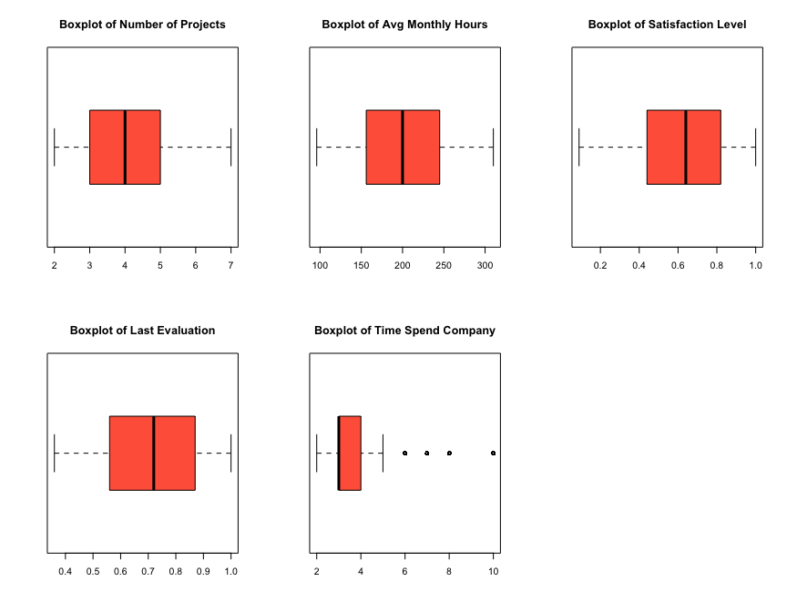

In order to detect **skewness** in our data, we do plot the histograms of the variables below and calculate the *skewness*() function. In order to evaluate our results on the skewness function we narrow the acceptable limits to (-2 , 2). So, it is decided that skewness is not a serious issue to be taken into account. Furthermore, the variable that needs scaling in order to reduce the impact it has on the models, cause of its excessive values compared to the rest, is the *average_monthly_hours*. The scaling of this variable is narrowed to the limits of (0,1).

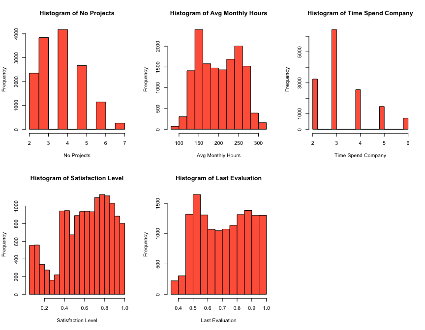

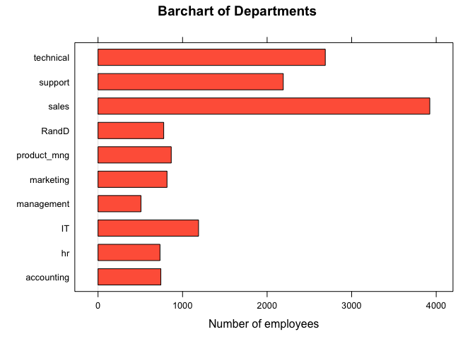

| Variable | Skewness Score |
| --- | --- |
| number_project | 0.3376 |
| average_montly_hours | 0.05283 |
| time_spend_company | 1.8529 |
| satisfaction_level | -0.4762 |
| last_evaluation | -0.0266 |

# Further Insights through Interesting Plots

As mentioned before *sales* and *salary* are factor variables. Based on the below depicted graphs we can observe the distribution of employees across different departments, as well as whether they have left (blue) the company or not (red). As it can be observed, the majority of the employees are in *Sales*, *Technical* and *Support*.

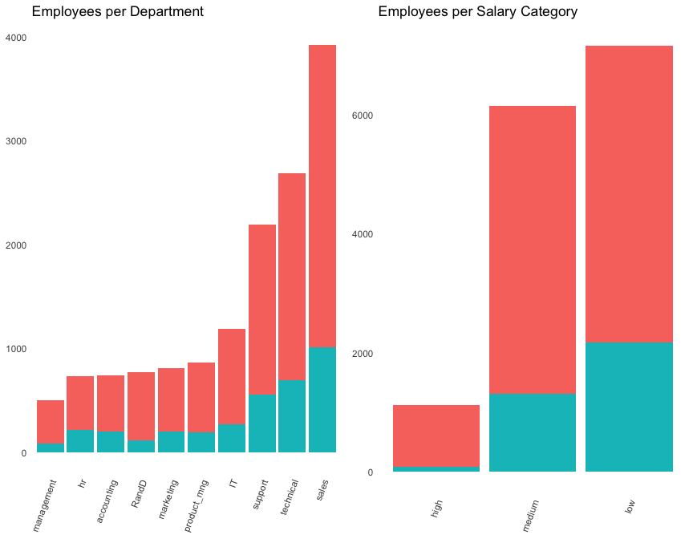

In the below mentioned **beeswarm** plot we can observe the connection between *satisfaction level* of employees, distributed based on how much *time* they have been at the company and splitted on whether we have information of them leaving or not. An interesting fact, is that at the time period **4** most of the employees are unsatisfied and do leave the company, while at time period **5** many of them leave as well but with a relative satisfying feeling.

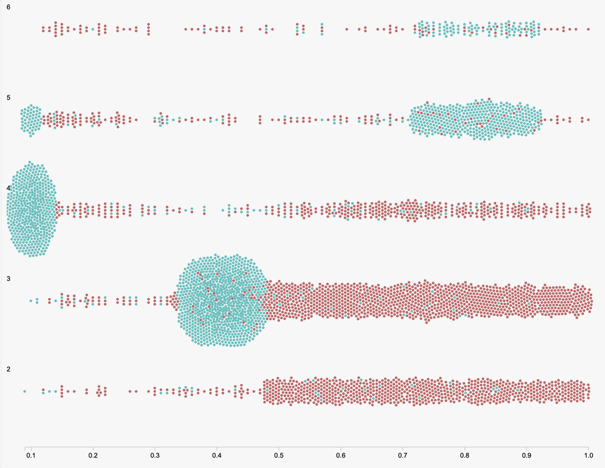

# Correlation Matrix & Factors unfolding

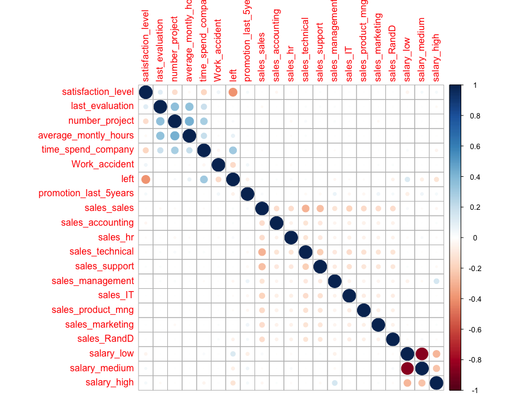

There are a few more things that can be done in order to improve our future model’s performace.

Grouping - Bining our variables *number_project*, *time_spend_company*, *promotion_last_5years* and *Work_accident*. The reason why the 3 continuous ones are not binned is the fact that we are thinking of applying polynomial functions to these 3 variables, to possibly improve the fitting of our model.

After doing these transformations and removing the initial columns to avoid *multicollinearity*, we plot once more the correlation matrix to find strong correlations between our variables.

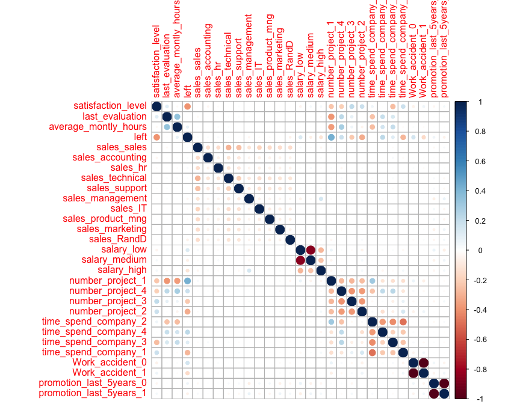

Some of the strongs **correlations** depicted above include the ones between *salary medium* and *salary low*, *work_accident_0* and *work_accident_1*, *promotion_last_5years_0* and *promotion_last_5years_1*. We should take these into account during our feature engineering process, in order to remove redundant variables from the model, to reduce complexity.

# Model Development

Now that we have our dataset cleaned and prepared to be used, we can develop our baseline **logistic regression model**. This model will be our benchmark for the rest of our model development process.

- We set our **seed** to make our process reproducable.
- Split to **trainingData** and **testData** with a proportion of 80% and 20% respectively.
- Define the **train_control** variable, which is basically the properites of the **Cross Validation** process we are going to use for our trained model.
- Develop our **model** with its formula.
- Look at the *summary*, *rfe* and *boruta* methods of the model:
- **Significant** variables to keep or remove from our model formula.
- **Average Cross Validation error** for our trained model on the training data.
- Make **predictions** on our testData (hold-out set) and compare with our CV error.
- **Repeate** the same process with *multiple seeds* in order to get an average accuracy score, to double check for overfitting.

# Baseline model

#### Summary of model

```
##
## Call:  NULL
##
## Coefficients:
##             (Intercept)       satisfaction_level          last_evaluation
##                -13.0402                  -2.5460                   2.5854
##    average_montly_hours              sales_sales         sales_accounting
##                  2.3905                   0.5805                   0.7046
##                sales_hr          sales_technical            sales_support
##                  0.8504                   0.7120                   0.6635
##        sales_management                 sales_IT        sales_product_mng
##                  0.3304                   0.4719                   0.3668
##         sales_marketing              sales_RandD               salary_low
##                  0.5852                       NA                   1.7646
##           salary_medium              salary_high         number_project_1
##                  1.3635                       NA                   5.5494
##        number_project_4         number_project_3         number_project_2
##                  2.2659                   1.3607                       NA
##    time_spend_company_2     time_spend_company_4     time_spend_company_3
##                  2.7391                   4.4431                   3.1349
##    time_spend_company_1          Work_accident_0          Work_accident_1
##                      NA                   1.5417                       NA
## promotion_last_5years_0  promotion_last_5years_1
##                  1.2124                       NA
##
## Degrees of Freedom: 11547 Total (i.e. Null);  11525 Residual
## Null Deviance:       12960
## Residual Deviance: 6632  AIC: 6678
```

#### Average 10-Fold Cross Validation Accuracy

```
##    Accuracy
## 1 0.8874267
```

#### Variables Importance

```
## glm variable importance
##
##   only 20 most important variables shown (out of 22)
##
##                         Overall
## number_project_1        100.000
## time_spend_company_4     67.678
## satisfaction_level       53.576
## time_spend_company_3     44.986
## number_project_4         42.915
## time_spend_company_2     42.104
## average_montly_hours     38.994
## Work_accident_0          36.013
## last_evaluation          30.069
## salary_low               28.798
## number_project_3         22.862
## salary_medium            21.008
## sales_technical           9.282
## sales_hr                  9.137
## sales_support             8.017
## sales_sales               7.075
## sales_accounting          6.790
## promotion_last_5years_0   5.817
## sales_marketing           4.776
## sales_IT                  3.648
```

#### Confusion Matrix

```
##
## fitted.results_1    0    1
##                0 2024  128
##                1  165  570
```

#### Accuracy on hold-out set.

```
## [1] "0.898510564599931"
```

#### Boruta or Backwards Elimination Approach

Boruta approach is a **Wrapper method** built around the random forest classification algorithm. The importance measure of an attribute is obtained as the loss of accuracy of classification caused by the random permutation of attribute values between objects.  
We decided to use this method cause:

- It works well for both classification and regression problem.
- It takes into account multi-variable relationships.
- It follows an all-relevant variable selection method in which it considers all features which are relevant to the outcome variable.

Some things to keep in mind for this algorithm are:

- **Impute missing values** - Make sure missing or blank values are filled up before running boruta algorithm.
- **Collinearity** - It is important to handle collinearity after getting important variables from boruta.
- **Slow Speed** - It is slow in terms of speed as compared to other traditional feature selection algorithms.

Variables having boxplot in green shows all predictors are important. If boxplots are in red, it shows they are rejected. And yellow color of box plot indicates they are tentative. Tentative Attributes refers to importance score so close to their best shadow attributes that Boruta is unable to decide in default number of random forest runs.

```
##  [1] "satisfaction_level"      "last_evaluation"
##  [3] "average_montly_hours"    "sales_sales"
##  [5] "sales_accounting"        "sales_technical"
##  [7] "sales_support"           "sales_management"
##  [9] "sales_RandD"             "salary_low"
## [11] "salary_medium"           "salary_high"
## [13] "number_project_1"        "number_project_4"
## [15] "number_project_3"        "number_project_2"
## [17] "time_spend_company_2"    "time_spend_company_4"
## [19] "time_spend_company_3"    "time_spend_company_1"
## [21] "Work_accident_0"         "Work_accident_1"
## [23] "promotion_last_5years_0" "promotion_last_5years_1"
```

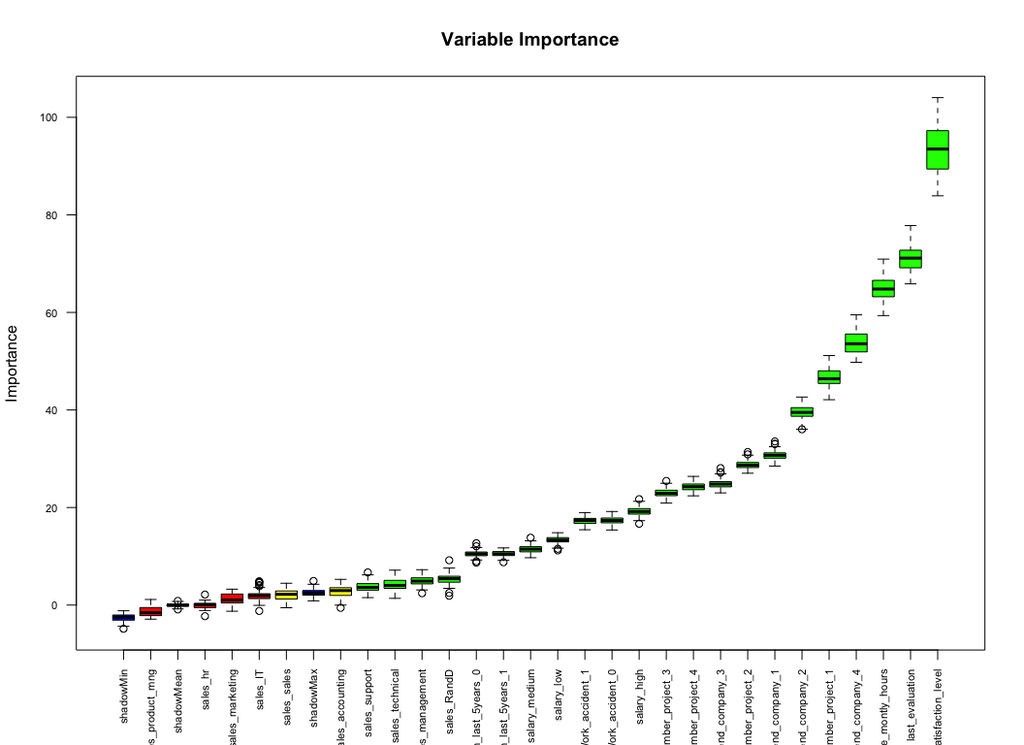

#### Recursive Feature Elimination (RFE) through Random Forest Development

There is also another variable selection algorithm called **recursive feature elimination (RFE)**. It is also called backward selection. Briefly, this algorithm *fits* the model using all the independent variables, calculates their *importance*, *ranks* and *drops* the weakest ones and *rebuilds* a model till all the variables are used. For our classification approach, the metric used is *Accuracy* and the model is a **Random Forest**.

#### Difference between **RFE** and **Boruta** Algorithms

```
##      satisfaction_level         last_evaluation    average_montly_hours
##            4.881149e-03            1.925159e-03            1.849847e-03
##             sales_sales        sales_accounting                sales_hr
##            0.000000e+00            4.706990e-06            0.000000e+00
##         sales_technical           sales_support        sales_management
##           -2.824194e-05           -9.413980e-06           -9.413980e-06
##                sales_IT       sales_product_mng         sales_marketing
##            0.000000e+00            4.706990e-06            0.000000e+00
##             sales_RandD              salary_low           salary_medium
##            0.000000e+00           -1.882796e-05            4.706990e-06
##             salary_high        number_project_1        number_project_4
##            0.000000e+00            4.706990e-05           -2.824194e-05
##        number_project_3        number_project_2    time_spend_company_2
##            0.000000e+00            1.365027e-04            3.765592e-05
##    time_spend_company_4    time_spend_company_3    time_spend_company_1
##            9.555189e-04            0.000000e+00            0.000000e+00
##         Work_accident_0         Work_accident_1 promotion_last_5years_0
##           -9.413980e-06            7.060485e-05            9.413980e-06
## promotion_last_5years_1
##            1.882796e-05
```

After we get a score for our baseline model we move on with removing the variables that are not significant based on their performance on:

- The **Boruta** and **Random Forest** approach
- The **varImp** function.
- Their **correlation** with other variables.

At this point we will depict the results of the intermediate models we came up with during our pipeline (and can be find in the actual code), along with the necessary transformations and actions, till we get to the final model which we will analyze once more. Worth mentioning that for each new model (apart from the last 2 in which we tune the polynomial function), the *boruta* and *rfe* approaches are used to determine whether the variables left are significant or not.

[output not shown]

#### Summary of final model.

```
##
## Call:  NULL
##
## Coefficients:
##                      (Intercept)   `poly(satisfaction_level, 11)1`
##                          -6.2387                         -878.2335
##  `poly(satisfaction_level, 11)2`   `poly(satisfaction_level, 11)3`
##                        -575.7512                        -1051.9912
##  `poly(satisfaction_level, 11)4`   `poly(satisfaction_level, 11)5`
##                        -718.6891                         -991.5702
##  `poly(satisfaction_level, 11)6`   `poly(satisfaction_level, 11)7`
##                        -448.4843                         -572.2949
##  `poly(satisfaction_level, 11)8`   `poly(satisfaction_level, 11)9`
##                        -284.2432                         -321.9310
## `poly(satisfaction_level, 11)10`  `poly(satisfaction_level, 11)11`
##                         -43.1857                         -117.7039
##      `poly(last_evaluation, 7)1`       `poly(last_evaluation, 7)2`
##                          73.6783                          -24.5868
##      `poly(last_evaluation, 7)3`       `poly(last_evaluation, 7)4`
##                         129.0993                         -148.6230
##      `poly(last_evaluation, 7)5`       `poly(last_evaluation, 7)6`
##                          91.3280                          -17.7808
##      `poly(last_evaluation, 7)7`  `poly(average_montly_hours, 9)1`
##                          39.1783                          803.1012
## `poly(average_montly_hours, 9)2`  `poly(average_montly_hours, 9)3`
##                        -536.1989                         1642.4304
## `poly(average_montly_hours, 9)4`  `poly(average_montly_hours, 9)5`
##                        -743.5706                         1314.9440
## `poly(average_montly_hours, 9)6`  `poly(average_montly_hours, 9)7`
##                        -321.4474                          648.0193
## `poly(average_montly_hours, 9)8`  `poly(average_montly_hours, 9)9`
##                        -123.3010                          256.4106
##                 sales_management                       sales_RandD
##                          -0.9657                           -0.5994
##                    salary_medium                  number_project_1
##                          -0.3296                            2.0721
##                 number_project_2                  number_project_3
##                          -1.5519                           -0.4114
##             time_spend_company_1              time_spend_company_2
##                          -4.0402                           -2.9388
##             time_spend_company_3                   Work_accident_0
##                          -2.5263                            1.3158
##
## Degrees of Freedom: 11547 Total (i.e. Null);  11510 Residual
## Null Deviance:       12960
## Residual Deviance: 3349  AIC: 3425
```

#### Average 10-Fold Cross Validation Accuracy

```
##    Accuracy
## 1 0.9599052
```

#### Variables Importance

```
## glm variable importance
##
##   only 20 most important variables shown (out of 37)
##
##                                  Overall
## time_spend_company_2              100.00
## time_spend_company_1               91.44
## time_spend_company_3               68.76
## number_project_1                   57.95
## number_project_2                   34.46
## Work_accident_0                    32.46
## `poly(average_montly_hours, 9)9`   30.86
## `poly(average_montly_hours, 9)5`   28.23
## `poly(average_montly_hours, 9)1`   27.21
## `poly(last_evaluation, 7)4`        26.53
## `poly(average_montly_hours, 9)7`   26.14
## `poly(average_montly_hours, 9)3`   26.09
## `poly(satisfaction_level, 11)1`    25.87
## `poly(satisfaction_level, 11)5`    25.42
## `poly(satisfaction_level, 11)11`   24.82
## `poly(satisfaction_level, 11)9`    24.32
## `poly(last_evaluation, 7)1`        23.27
## `poly(satisfaction_level, 11)3`    21.79
## `poly(satisfaction_level, 11)7`    21.79
## `poly(last_evaluation, 7)5`        19.64
```

#### Confusion Matrix

```
##
## fitted.results_6    0    1
##                0 2135   52
##                1   54  646
```

#### Accuracy on hold-out set.

```
## [1] "0.963283685486664"
```

## Different Train - Test splits to check for overfitting.

As we deided to incorporate high degrees of polynomials to our model, we need to check for *overfitting.* In order to do that, we tested our model with **50** different splits (50 different seeds). We write down the *CV score* and the *Actual accuracy* to the Hold-Out set and after that we take the average values that correspond to the* real accuracy* of our model.

| Seeds | Avg CV Accuracy | Accuracy on Hold-Out | Seeds | Avg CV Accuracy | Accuracy on Hold-Out | Avg CV Accuracy Total | Accuracy on Hold-Out Total |
| --- | --- | --- | --- | --- | --- | --- | --- |
| 100 | 0.9627 | 0.9550 | 2600 | 0.9608 | 0.9633 | **0.9605** | **0.9615** |
| 200 | 0.9611 | 0.9591 | 2700 | 0.9613 | 0.9588 |  |  |
| 300 | 0.9614 | 0.9602 | 2800 | 0.9602 | 0.9633 |  |  |
| 400 | 0.9603 | 0.9640 | 2900 | 0.9610 | 0.9616 |  |  |
| 500 | 0.9610 | 0.9605 | 3000 | 0.9609 | 0.9640 |  |  |
| 600 | 0.9615 | 0.9595 | 3100 | 0.9598 | 0.9584 |  |  |
| 700 | 0.9607 | 0.9595 | 3200 | 0.9597 | 0.9605 |  |  |
| 800 | 0.9594 | 0.9619 | 3300 | 0.9617 | 0.9602 |  |  |
| 900 | 0.9603 | 0.9616 | 3400 | 0.9586 | 0.9671 |  |  |
| 1000 | 0.9596 | 0.9667 | 3500 | 0.9600 | 0.9591 |  |  |
| 1100 | 0.9615 | 0.9567 | 3600 | 0.9586 | 0.9657 |  |  |
| 1200 | 0.9621 | 0.9577 | 3700 | 0.9596 | 0.9661 |  |  |
| 1300 | 0.9602 | 0.9616 | 3800 | 0.9605 | 0.9661 |  |  |
| 1400 | 0.9607 | 0.9591 | 3900 | 0.9610 | 0.9570 |  |  |
| 1500 | 0.9617 | 0.9584 | 4000 | 0.9624 | 0.9557 |  |  |
| 1600 | 0.9596 | 0.9626 | 4100 | 0.9597 | 0.9657 |  |  |
| 1700 | 0.9609 | 0.9609 | 4200 | 0.9604 | 0.9622 |  |  |
| 1800 | 0.9587 | 0.9619 | 4300 | 0.9626 | 0.9564 |  |  |
| 1900 | 0.9615 | 0.9584 | 4400 | 0.9599 | 0.9654 |  |  |
| 2000 | 0.9604 | 0.9633 | 4500 | 0.9595 | 0.9626 |  |  |
| 2100 | 0.9606 | 0.9622 | 4600 | 0.9595 | 0.9622 |  |  |
| 2200 | 0.9608 | 0.9633 | 4700 | 0.9595 | 0.9654 |  |  |
| 2300 | 0.9600 | 0.9629 | 4800 | 0.9599 | 0.9636 |  |  |
| 2400 | 0.9598 | 0.9636 | 4900 | 0.9605 | 0.9622 |  |  |
| 2500 | 0.9609 | 0.9616 | 5000 | 0.9613 | 0.9595 |  |  |

# Conclusions

However, this model development refers only to this specific split. In order to *verify* that our model is able to generalize that good, we reproduce the same pipeline for **different splits**, which means different *seeds* in our code.

It is worth noticing, that all the values are pretty close for the different splits, which leads to the conclusion that our model is able to *generalize pretty well* and is able to perform *efficiently* in unseen data.

Regarding the predictors we end up with are:

| **Final Explanatory Variables** |  |  |
| --- | --- | --- |
| satisfaction_level | last_evaluation | average_montly_hours |
| salary_medium | number_project_1 | number_project_2 |
| number_project_3 | time_spend_company_1 | time_spend_company_2 |
| time_spend_company_3 | Work_accident_0 | sales_management |
| sales_management | sales_RandD |  |

Based on the above mentioned results we conclude that factors that affect whether an employee left or not are:

- How **satisfied** the employees are.
- How they well were they **evaluated.**
- How many hours do they work on average.
- Whether they work on **2, 3 or 4** projects.
- Whether they have been at the company for **2, 3 or 4** years.
- That they did *not* have a **work accident**.